# Task1

The Sparks Foundation Data Science and Business Analytics (Grip 2021) Task 1 : Prediction using Supervised ML Problem : predict the percentage of students based on no. of study hours. Author: Venepally Tharun

1. Importing all Libraries required

```python
#importing libraries
import pandas as pd
import numpy as np
import matplotlib.pyplot as plt
%matplotlib inline
import seaborn as sns #for data visualisation.
```

1. Reading Dataset

```python
#Reading data from link
url = r"http://bit.ly/w-data"
df = pd.read_csv(url)
print("Data imported successfully")
```

```
Data imported successfully
```

```python
#printing first 10 rows of the data set.
df.head(10)
```

|  | Hours | Scores |
| --- | --- | --- |
| 0 | 2.5 | 21 |
| 1 | 5.1 | 47 |
| 2 | 3.2 | 27 |
| 3 | 8.5 | 75 |
| 4 | 3.5 | 30 |
| 5 | 1.5 | 20 |
| 6 | 9.2 | 88 |
| 7 | 5.5 | 60 |
| 8 | 8.3 | 81 |
| 9 | 2.7 | 25 |

```python
#checking the number of rows and columns.
df.shape
```

```
(25, 2)
```

```python
df.describe()
```

|  | Hours | Scores |
| --- | --- | --- |
| count | 25.000000 | 25.000000 |
| mean | 5.012000 | 51.480000 |
| std | 2.525094 | 25.286887 |
| min | 1.100000 | 17.000000 |
| 25% | 2.700000 | 30.000000 |
| 50% | 4.800000 | 47.000000 |
| 75% | 7.400000 | 75.000000 |
| max | 9.200000 | 95.000000 |

```python
df.info()
```

```
<class 'pandas.core.frame.DataFrame'>
RangeIndex: 25 entries, 0 to 24
Data columns (total 2 columns):
 #   Column  Non-Null Count  Dtype
---  ------  --------------  -----
 0   Hours   25 non-null     float64
 1   Scores  25 non-null     int64
dtypes: float64(1), int64(1)
memory usage: 528.0 bytes
```

```python
#check if there is any null value in the dataset.
df.isnull().sum()
```

```
Hours     0
Scores    0
dtype: int64
```

3 . DATA VISUALISATION

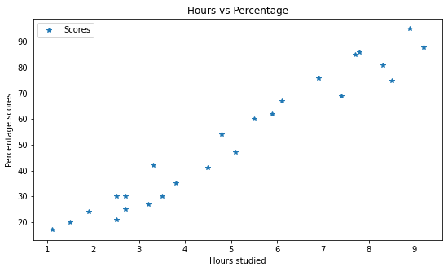

```python
#Plotting the graph to see the relation and distribution of datapoints.
df.plot(x = 'Hours', y = 'Scores', figsize = (9,5), style = '*')
plt.title('Hours vs Percentage')
plt.xlabel('Hours studied')
plt.ylabel('Percentage scores')
plt.show()
```

from the above graph we can see that there is positive linear relation between the no of hours studied and percentage scores.

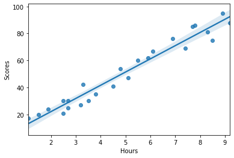

```python
sns.regplot( x = 'Hours', y = 'Scores', data = df)
```

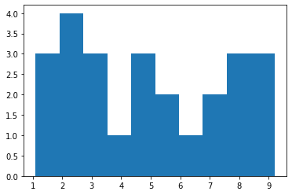

```python
#Distribution of hours data
plt.hist(x = 'Hours', data = df)
plt.show()
```

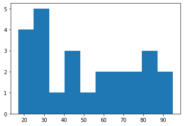

```python
#Distribution of scores data
plt.hist(x = 'Scores', data = df)
plt.show()
```

4 . DATA PREPARATION

```python
#dividing the datasets int attributes(inputs) and labels(columns)
x = df.iloc[:,:-1].values
y = df.iloc[:,1].values
```

slpit this data into train and testdata using the train_test_split() method from the skicit learn library.

```python
from sklearn.model_selection import train_test_split
x_train,x_test,y_train,y_test = train_test_split(x,y,test_size = 0.2, random_state = 0)
```

5 . TRAINING THE MODEL we have to train our data using Linear regression algorithm and check the values for test data

```python
from sklearn.linear_model import LinearRegression
lr = LinearRegression()
lr.fit(x_train,y_train)
LinearRegression(copy_X=True, fit_intercept=True, n_jobs=None, normalize=False)
```

```
LinearRegression()
```

plot the regression line in the scatter

```python
r_line = lr.coef_*x+lr.intercept_
```

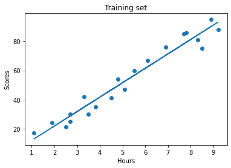

```python
#visualising the training dataset
plt.scatter(x_train, y_train)
plt.title('Training set')
plt.plot(x_train,lr.predict(x_train))
plt.xlabel("Hours")
plt.ylabel("Scores")
```

6 . MAKING PREDICTIONS

we have done tarining and we have to make some predictions.

```python
y_pred = lr.predict(x_test)
y_pred
```

```
array([16.88414476, 33.73226078, 75.357018  , 26.79480124, 60.49103328])
```

```python
df = pd.DataFrame({"Actual":y_test,"Predicted":y_test})
df
```

|  | Actual | Predicted |
| --- | --- | --- |
| 0 | 20 | 20 |
| 1 | 27 | 27 |
| 2 | 69 | 69 |
| 3 | 30 | 30 |
| 4 | 62 | 62 |

```python
#score for test data
accuracy = lr.score(x_test, y_test)
print("Accuracy:",accuracy * 100)
```

```
Accuracy: 94.54906892105356
```

what is the predicted score if student studies for 9.25 hours per day?

```python
# we can test for any input
# here we are calculating the score for 9.25 hours
hours = [[9.25]]
pred = lr.predict(hours)
pred
```

```
array([93.69173249])
```

1. MODEL EVALUATION

In this step we have to evaluate the performance of algorithm. we can evaluate this by calculating mean squared error or mean absolute error.

MEAN ABSOLUTE ERROR

```python
from sklearn import metrics
MAE = metrics.mean_absolute_error(y_test,y_pred)
print("Mean Absolute Error: ", MAE)
```

```
Mean Absolute Error:  4.183859899002975
```

MEAN SQUARED ERROR

```python
from sklearn import metrics
MSE = metrics.mean_squared_error(y_test,y_pred)
print("Mean Squared Error: ", MSE)
```

```
Mean Squared Error:  21.5987693072174
```

Small value of Mean Absolute Error states that the model is quite good.

THANK YOU.